# Cyclistic Bike-Share Data Analysis

Hamza Jawad

2025-08-20

# 1 Introduction

This report presents an analysis of the **Cyclistic bike-share program**, following the structured data analysis process:

- **Ask Phase**: Define the business task.
- **Prepare Phase**: Import and explore the datasets.
- **Process Phase**: Clean and transform the datasets.
- **Analyze Phase**: Generate descriptive and comparative statistics.
- **Share Phase**: Visualize and communicate insights.

# 2 Ask Phase

### 2.0.1 Business Task:

How do annual members and casual riders use Cyclistic bikes differently?

### 2.0.2 Business Statement:

This project analyzes historical trip data from **Q1 2019** and **Q1 2020** to identify patterns and trends in how casual riders and annual members use Cyclistic bikes. The findings will be used to provide actionable recommendations for converting more casual riders into annual members, directly supporting Cyclistic’s goal of increasing long-term customer retention and revenue.

# 3 Prepare Phase

### 3.0.1 Load Required Libraries

```r
library(tidyverse)
library(lubridate)
library(janitor)
library(skimr)
library(scales)
library(dplyr)
library(readr)
library(ggplot2)
```

### 3.0.2 Import Q1 2019 and Q1 2020 datasets

```r
divvy_trips_2019_df <- read_csv("F:/Google_Data_Analysis/case_studies/case_study_1/case_study_1_datasets/Divvy_Trips_2019_Q1.csv")
divvy_trips_2020_df <- read_csv("F:/Google_Data_Analysis/case_studies/case_study_1/case_study_1_datasets/Divvy_Trips_2020_Q1.csv")
```

## 3.1 Inspect the datasets

### 3.1.1 Check first five rows of each dataset

```r
knitr::kable(head(divvy_trips_2019_df, 5))
```

| trip_id | start_time | end_time | bikeid | tripduration | from_station_id | from_station_name | to_station_id | to_station_name | usertype | gender | birthyear |
| --- | --- | --- | --- | --- | --- | --- | --- | --- | --- | --- | --- |
| 21742443 | 2019-01-01 0:04:37 | 2019-01-01 0:11:07 | 2167 | 390 | 199 | Wabash Ave & Grand Ave | 84 | Milwaukee Ave & Grand Ave | Subscriber | Male | 1989 |
| 21742444 | 2019-01-01 0:08:13 | 2019-01-01 0:15:34 | 4386 | 441 | 44 | State St & Randolph St | 624 | Dearborn St & Van Buren St (*) | Subscriber | Female | 1990 |
| 21742445 | 2019-01-01 0:13:23 | 2019-01-01 0:27:12 | 1524 | 829 | 15 | Racine Ave & 18th St | 644 | Western Ave & Fillmore St (*) | Subscriber | Female | 1994 |
| 21742446 | 2019-01-01 0:13:45 | 2019-01-01 0:43:28 | 252 | 1783 | 123 | California Ave & Milwaukee Ave | 176 | Clark St & Elm St | Subscriber | Male | 1993 |
| 21742447 | 2019-01-01 0:14:52 | 2019-01-01 0:20:56 | 1170 | 364 | 173 | Mies van der Rohe Way & Chicago Ave | 35 | Streeter Dr & Grand Ave | Subscriber | Male | 1994 |

```r
knitr::kable(head(divvy_trips_2020_df, 5))
```

| ride_id | rideable_type | started_at | ended_at | start_station_name | start_station_id | end_station_name | end_station_id | start_lat | start_lng | end_lat | end_lng | member_casual |
| --- | --- | --- | --- | --- | --- | --- | --- | --- | --- | --- | --- | --- |
| EACB19130B0CDA4A | docked_bike | 2020-01-21 20:06:59 | 2020-01-21 20:14:30 | Western Ave & Leland Ave | 239 | Clark St & Leland Ave | 326 | 41.9665 | -87.6884 | 41.9671 | -87.6674 | member |
| 8FED874C809DC021 | docked_bike | 2020-01-30 14:22:39 | 2020-01-30 14:26:22 | Clark St & Montrose Ave | 234 | Southport Ave & Irving Park Rd | 318 | 41.9616 | -87.6660 | 41.9542 | -87.6644 | member |
| 789F3C21E472CA96 | docked_bike | 2020-01-09 19:29:26 | 2020-01-09 19:32:17 | Broadway & Belmont Ave | 296 | Wilton Ave & Belmont Ave | 117 | 41.9401 | -87.6455 | 41.9402 | -87.6530 | member |
| C9A388DAC6ABF313 | docked_bike | 2020-01-06 16:17:07 | 2020-01-06 16:25:56 | Clark St & Randolph St | 51 | Fairbanks Ct & Grand Ave | 24 | 41.8846 | -87.6319 | 41.8918 | -87.6206 | member |
| 943BC3CBECCFD662 | docked_bike | 2020-01-30 8:37:16 | 2020-01-30 8:42:48 | Clinton St & Lake St | 66 | Wells St & Hubbard St | 212 | 41.8856 | -87.6418 | 41.8899 | -87.6343 | member |

### 3.1.2 Check column names

```r
colnames(divvy_trips_2019_df)
```

```
##  [1] "trip_id"           "start_time"        "end_time"
##  [4] "bikeid"            "tripduration"      "from_station_id"
##  [7] "from_station_name" "to_station_id"     "to_station_name"
## [10] "usertype"          "gender"            "birthyear"
```

```r
colnames(divvy_trips_2020_df)
```

```
##  [1] "ride_id"            "rideable_type"      "started_at"
##  [4] "ended_at"           "start_station_name" "start_station_id"
##  [7] "end_station_name"   "end_station_id"     "start_lat"
## [10] "start_lng"          "end_lat"            "end_lng"
## [13] "member_casual"
```

### 3.1.3 Check structure of each dataset

```r
str(divvy_trips_2019_df)
```

```
## spc_tbl_ [365,069 × 12] (S3: spec_tbl_df/tbl_df/tbl/data.frame)
##  $ trip_id          : num [1:365069] 21742443 21742444 21742445 21742446 21742447 ...
##  $ start_time       : chr [1:365069] "2019-01-01 0:04:37" "2019-01-01 0:08:13" "2019-01-01 0:13:23" "2019-01-01 0:13:45" ...
##  $ end_time         : chr [1:365069] "2019-01-01 0:11:07" "2019-01-01 0:15:34" "2019-01-01 0:27:12" "2019-01-01 0:43:28" ...
##  $ bikeid           : num [1:365069] 2167 4386 1524 252 1170 ...
##  $ tripduration     : num [1:365069] 390 441 829 1783 364 ...
##  $ from_station_id  : num [1:365069] 199 44 15 123 173 98 98 211 150 268 ...
##  $ from_station_name: chr [1:365069] "Wabash Ave & Grand Ave" "State St & Randolph St" "Racine Ave & 18th St" "California Ave & Milwaukee Ave" ...
##  $ to_station_id    : num [1:365069] 84 624 644 176 35 49 49 142 148 141 ...
##  $ to_station_name  : chr [1:365069] "Milwaukee Ave & Grand Ave" "Dearborn St & Van Buren St (*)" "Western Ave & Fillmore St (*)" "Clark St & Elm St" ...
##  $ usertype         : chr [1:365069] "Subscriber" "Subscriber" "Subscriber" "Subscriber" ...
##  $ gender           : chr [1:365069] "Male" "Female" "Female" "Male" ...
##  $ birthyear        : num [1:365069] 1989 1990 1994 1993 1994 ...
##  - attr(*, "spec")=
##   .. cols(
##   ..   trip_id = col_double(),
##   ..   start_time = col_character(),
##   ..   end_time = col_character(),
##   ..   bikeid = col_double(),
##   ..   tripduration = col_number(),
##   ..   from_station_id = col_double(),
##   ..   from_station_name = col_character(),
##   ..   to_station_id = col_double(),
##   ..   to_station_name = col_character(),
##   ..   usertype = col_character(),
##   ..   gender = col_character(),
##   ..   birthyear = col_double()
##   .. )
##  - attr(*, "problems")=<externalptr>
```

```r
str(divvy_trips_2020_df)
```

```
## spc_tbl_ [426,887 × 13] (S3: spec_tbl_df/tbl_df/tbl/data.frame)
##  $ ride_id           : chr [1:426887] "EACB19130B0CDA4A" "8FED874C809DC021" "789F3C21E472CA96" "C9A388DAC6ABF313" ...
##  $ rideable_type     : chr [1:426887] "docked_bike" "docked_bike" "docked_bike" "docked_bike" ...
##  $ started_at        : chr [1:426887] "2020-01-21 20:06:59" "2020-01-30 14:22:39" "2020-01-09 19:29:26" "2020-01-06 16:17:07" ...
##  $ ended_at          : chr [1:426887] "2020-01-21 20:14:30" "2020-01-30 14:26:22" "2020-01-09 19:32:17" "2020-01-06 16:25:56" ...
##  $ start_station_name: chr [1:426887] "Western Ave & Leland Ave" "Clark St & Montrose Ave" "Broadway & Belmont Ave" "Clark St & Randolph St" ...
##  $ start_station_id  : num [1:426887] 239 234 296 51 66 212 96 96 212 38 ...
##  $ end_station_name  : chr [1:426887] "Clark St & Leland Ave" "Southport Ave & Irving Park Rd" "Wilton Ave & Belmont Ave" "Fairbanks Ct & Grand Ave" ...
##  $ end_station_id    : num [1:426887] 326 318 117 24 212 96 212 212 96 100 ...
##  $ start_lat         : num [1:426887] 42 42 41.9 41.9 41.9 ...
##  $ start_lng         : num [1:426887] -87.7 -87.7 -87.6 -87.6 -87.6 ...
##  $ end_lat           : num [1:426887] 42 42 41.9 41.9 41.9 ...
##  $ end_lng           : num [1:426887] -87.7 -87.7 -87.7 -87.6 -87.6 ...
##  $ member_casual     : chr [1:426887] "member" "member" "member" "member" ...
##  - attr(*, "spec")=
##   .. cols(
##   ..   ride_id = col_character(),
##   ..   rideable_type = col_character(),
##   ..   started_at = col_character(),
##   ..   ended_at = col_character(),
##   ..   start_station_name = col_character(),
##   ..   start_station_id = col_double(),
##   ..   end_station_name = col_character(),
##   ..   end_station_id = col_double(),
##   ..   start_lat = col_double(),
##   ..   start_lng = col_double(),
##   ..   end_lat = col_double(),
##   ..   end_lng = col_double(),
##   ..   member_casual = col_character()
##   .. )
##  - attr(*, "problems")=<externalptr>
```

### 3.1.4 Get a summary overview

```r
skim_without_charts(divvy_trips_2019_df)
```

Data summary

| Name | divvy_trips_2019_df |
| --- | --- |
| Number of rows | 365069 |
| Number of columns | 12 |
| _______________________ |  |
| Column type frequency: |  |
| character | 6 |
| numeric | 6 |
| ________________________ |  |
| Group variables | None |

**Variable type: character**

| skim_variable | n_missing | complete_rate | min | max | empty | n_unique | whitespace |
| --- | --- | --- | --- | --- | --- | --- | --- |
| start_time | 0 | 1.00 | 18 | 19 | 0 | 343022 | 0 |
| end_time | 0 | 1.00 | 18 | 19 | 0 | 338367 | 0 |
| from_station_name | 0 | 1.00 | 10 | 43 | 0 | 594 | 0 |
| to_station_name | 0 | 1.00 | 10 | 43 | 0 | 600 | 0 |
| usertype | 0 | 1.00 | 8 | 10 | 0 | 2 | 0 |
| gender | 19711 | 0.95 | 4 | 6 | 0 | 2 | 0 |

**Variable type: numeric**

| skim_variable | n_missing | complete_rate | mean | sd | p0 | p25 | p50 | p75 | p100 |
| --- | --- | --- | --- | --- | --- | --- | --- | --- | --- |
| trip_id | 0 | 1.00 | 21960871.66 | 127175.00 | 21742443 | 21848765 | 21961829 | 22071823 | 22178528 |
| bikeid | 0 | 1.00 | 3429.48 | 1923.32 | 1 | 1777 | 3489 | 5157 | 6471 |
| tripduration | 0 | 1.00 | 1016.34 | 27913.51 | 61 | 326 | 524 | 866 | 10628400 |
| from_station_id | 0 | 1.00 | 198.09 | 153.49 | 2 | 76 | 170 | 287 | 665 |
| to_station_id | 0 | 1.00 | 198.58 | 154.47 | 2 | 76 | 168 | 287 | 665 |
| birthyear | 18023 | 0.95 | 1981.67 | 11.25 | 1900 | 1975 | 1985 | 1990 | 2003 |

```r
skim_without_charts(divvy_trips_2020_df)
```

Data summary

| Name | divvy_trips_2020_df |
| --- | --- |
| Number of rows | 426887 |
| Number of columns | 13 |
| _______________________ |  |
| Column type frequency: |  |
| character | 7 |
| numeric | 6 |
| ________________________ |  |
| Group variables | None |

**Variable type: character**

| skim_variable | n_missing | complete_rate | min | max | empty | n_unique | whitespace |
| --- | --- | --- | --- | --- | --- | --- | --- |
| ride_id | 0 | 1 | 8 | 16 | 0 | 426887 | 0 |
| rideable_type | 0 | 1 | 11 | 11 | 0 | 1 | 0 |
| started_at | 0 | 1 | 18 | 19 | 0 | 399265 | 0 |
| ended_at | 0 | 1 | 18 | 19 | 0 | 399532 | 0 |
| start_station_name | 0 | 1 | 5 | 43 | 0 | 607 | 0 |
| end_station_name | 1 | 1 | 5 | 43 | 0 | 602 | 0 |
| member_casual | 0 | 1 | 6 | 6 | 0 | 2 | 0 |

**Variable type: numeric**

| skim_variable | n_missing | complete_rate | mean | sd | p0 | p25 | p50 | p75 | p100 |
| --- | --- | --- | --- | --- | --- | --- | --- | --- | --- |
| start_station_id | 0 | 1 | 209.80 | 163.22 | 2.00 | 77.00 | 176.00 | 298.00 | 675.00 |
| end_station_id | 1 | 1 | 209.34 | 163.20 | 2.00 | 77.00 | 175.00 | 297.00 | 675.00 |
| start_lat | 0 | 1 | 41.90 | 0.04 | 41.74 | 41.88 | 41.89 | 41.92 | 42.06 |
| start_lng | 0 | 1 | -87.64 | 0.02 | -87.77 | -87.66 | -87.64 | -87.63 | -87.55 |
| end_lat | 1 | 1 | 41.90 | 0.04 | 41.74 | 41.88 | 41.89 | 41.92 | 42.06 |
| end_lng | 1 | 1 | -87.64 | 0.02 | -87.77 | -87.66 | -87.64 | -87.63 | -87.55 |

# 4 Process Phase

## 4.1 Cleaning the Datasets

To prepare the 2019 and 2020 datasets for analysis, I applied the following steps:

- Renamed columns for consistency.
- Converted start and end times to proper datetime format.
- Cleaned station names by removing unwanted symbols.
- Standardized user types (`subscriber → member`, `customer → casual`).
- Removed null values, duplicates, and unrealistic ride durations.
- Created new variables such as ride length, day of week, month, and year.
- Standardized the schema of both datasets.
- Merge both cleaned datasets to analyze the data.

### 4.1.1 Code for cleaning of 2019 dataset

```r
divvy_trips_2019_df <- divvy_trips_2019_df %>%
  # Convert date-time columns and drop original character columns
  mutate(
    started_at = ymd_hms(start_time),
    ended_at = ymd_hms(end_time)
  ) %>%
  select(-start_time, -end_time) %>%

  # Remove rows with missing critical values
  filter(!is.na(trip_id), !is.na(started_at), !is.na(ended_at)) %>%

  # Clean station names (remove extra spaces and "(*)")
  mutate(
    from_station_name = str_squish(str_remove_all(from_station_name,"\\(\\*\\)")),
    to_station_name   = str_squish(str_remove_all(to_station_name,"\\(\\*\\)"))
  ) %>%

  # Standardize usertype column → member_casual
  mutate(
    member_casual = case_when(
      str_to_lower(usertype) == "subscriber" ~ "member",
      str_to_lower(usertype) == "customer"   ~ "casual",
      TRUE ~ NA_character_
    )
  ) %>%
  filter(!is.na(member_casual)) %>%
  select(-usertype) %>%

  # Create derived columns
  mutate(
    ride_length_min = as.numeric(difftime(ended_at, started_at, units = "mins")),
    day_of_week     = wday(started_at, label = TRUE, abbr = TRUE, week_start = 1),
    month           = month(started_at, label = TRUE, abbr = TRUE),
    year            = year(started_at)
  ) %>%

  # Filter out rides < 1 min or > 24 hrs
  filter(ride_length_min >= 1 & ride_length_min <= 24*60) %>%

  # Drop unnecessary columns
  select(-gender, -birthyear, -bikeid) %>%

  # Remove duplicates
  distinct() %>%

  # Standardize final schema
  transmute(
    ride_id        = as.character(trip_id),
    rideable_type  = "docked_bike",
    started_at,
    ended_at,
    start_station_name = from_station_name,
    start_station_id   = as.character(from_station_id),
    end_station_name   = to_station_name,
    end_station_id     = as.character(to_station_id),
    member_casual,
    ride_length_min,
    day_of_week,
    month,
    year
  )
```

### 4.1.2 Code for cleaning of 2020 dataset

```r
divvy_trips_2020_df <- divvy_trips_2020_df %>%
  # Drop unnecessary lat/lng columns
  select(-start_lat, -start_lng, -end_lat, -end_lng) %>%

  # Convert date-time columns
  mutate(
    started_at = ymd_hms(started_at),
    ended_at   = ymd_hms(ended_at)
  ) %>%

  # Create derived columns
  mutate(
    ride_length_min = as.numeric(difftime(ended_at, started_at, units = "mins")),
    day_of_week     = wday(started_at, label = TRUE, abbr = TRUE, week_start = 1),
    month           = month(started_at, label = TRUE, abbr = TRUE),
    year            = year(started_at)
  ) %>%

  # Clean station names (remove extra spaces and "(*)")
  mutate(
    start_station_name = str_squish(str_remove_all(start_station_name,"\\(\\*\\)")),
    end_station_name   = str_squish(str_remove_all(end_station_name,"\\(\\*\\)"))
  ) %>%

  # Remove rows with missing critical values
  filter(!is.na(ride_id), !is.na(started_at), !is.na(ended_at)) %>%

  # Filter out rides < 1 min or > 24 hrs
  filter(ride_length_min >= 1 & ride_length_min <= 24*60) %>%

  # Remove duplicates
  distinct() %>%

  # Standardize final schema
  transmute(
    ride_id        = as.character(ride_id),
    rideable_type,
    started_at,
    ended_at,
    start_station_name,
    start_station_id   = as.character(start_station_id),
    end_station_name,
    end_station_id     = as.character(end_station_id),
    member_casual,
    ride_length_min,
    day_of_week,
    month,
    year
  )
```

### 4.1.3 Merge both cleaned datasets

```r
all_trips_df <- bind_rows(divvy_trips_2019_df, divvy_trips_2020_df)
```

### 4.1.4 Check first five rows of final dataset

```r
knitr::kable(head(all_trips_df, 5))
```

| ride_id | rideable_type | started_at | ended_at | start_station_name | start_station_id | end_station_name | end_station_id | member_casual | ride_length_min | day_of_week | month | year |
| --- | --- | --- | --- | --- | --- | --- | --- | --- | --- | --- | --- | --- |
| 21742443 | docked_bike | 2019-01-01 00:04:37 | 2019-01-01 00:11:07 | Wabash Ave & Grand Ave | 199 | Milwaukee Ave & Grand Ave | 84 | member | 6.500000 | Tue | Jan | 2019 |
| 21742444 | docked_bike | 2019-01-01 00:08:13 | 2019-01-01 00:15:34 | State St & Randolph St | 44 | Dearborn St & Van Buren St | 624 | member | 7.350000 | Tue | Jan | 2019 |
| 21742445 | docked_bike | 2019-01-01 00:13:23 | 2019-01-01 00:27:12 | Racine Ave & 18th St | 15 | Western Ave & Fillmore St | 644 | member | 13.816667 | Tue | Jan | 2019 |
| 21742446 | docked_bike | 2019-01-01 00:13:45 | 2019-01-01 00:43:28 | California Ave & Milwaukee Ave | 123 | Clark St & Elm St | 176 | member | 29.716667 | Tue | Jan | 2019 |
| 21742447 | docked_bike | 2019-01-01 00:14:52 | 2019-01-01 00:20:56 | Mies van der Rohe Way & Chicago Ave | 173 | Streeter Dr & Grand Ave | 35 | member | 6.066667 | Tue | Jan | 2019 |

# 5 Analyze Phase

After cleaning and merging the datasets, I performed several descriptive and comparative analyses to understand how members and casual riders use Cyclistic bikes differently.

The following analyses were conducted:

### 5.0.1 Code for Descriptive and Comparative Analysis

```r
# Load the cleaned dataset
all_trips_df <- read_csv("F:/Google_Data_Analysis/case_studies/case_study_1/case_study_1_datasets/cleaned_merged_dataset_2019_2020.csv")

# Ride length stats (mean, max, min)
max_min_mean <- all_trips_df %>%
  summarize(
    average_ride_length = mean(ride_length_min),
    max_ride_length = max(ride_length_min),
    min_ride_length = min(ride_length_min)
  )

# Mode of day_of_week
day_mode <- all_trips_df %>%
  count(day_of_week) %>%
  arrange(desc(n)) %>%
  slice(1)

# Average ride length by member type
average_ride_length_for_each_group <- all_trips_df %>%
  group_by(member_casual) %>%
  summarize(average = mean(ride_length_min))

# Average ride length by day_of_week and user type
average_ride_length_for_each_group_by_day <- all_trips_df %>%
  group_by(member_casual, day_of_week) %>%
  summarize(average = mean(ride_length_min))

# Number of rides by day_of_week
num_of_rides <- all_trips_df %>%
  group_by(member_casual, day_of_week) %>%
  summarize(ride_count = n())

# Add season variable
all_trips_df <- all_trips_df %>%
  mutate(
    season = case_when(
      month %in% c("Dec", "Jan", "Feb") ~ "Winter",
      month %in% c("Mar", "Apr", "May") ~ "Spring",
      month %in% c("Jun", "Jul", "Aug") ~ "Summer",
      TRUE ~ "Autumn"
    )
  )

# Rides by season
number_of_rides_by_season_for_each_group <- all_trips_df %>%
  group_by(season, member_casual) %>%
  summarize(num_rides = n())

# Average ride length by season
average_ride_length_by_season_for_each_group <- all_trips_df %>%
  group_by(season, member_casual) %>%
  summarize(avg_ride_length = mean(ride_length_min))

# Rides by month
number_of_rides_by_month_for_each_group <- all_trips_df %>%
  group_by(month, member_casual) %>%
  summarize(num_rides = n())

# Add time of day variable
all_trips_df <- all_trips_df %>%
  mutate(
    hour = hour(started_at),
    time_of_day = case_when(
      hour %in% 5:11 ~ "Morning",
      hour %in% 12:16 ~ "Afternoon",
      hour %in% 17:20 ~ "Evening",
      TRUE ~ "Night"
    )
  )

# Rides by time of day
number_of_rides_by_time_of_day_for_each_group <- all_trips_df %>%
  group_by(time_of_day, member_casual) %>%
  summarize(num_rides = n())

# Top 10 popular stations overall
ten_most_popular_stations <- all_trips_df %>%
  count(start_station_name, member_casual) %>%
  arrange(desc(n)) %>%
  slice(1:10)

# Top 10 popular stations by user type
ten_most_popular_stations_for_each_group <- all_trips_df %>%
  count(start_station_name, member_casual) %>%
  arrange(member_casual, desc(n)) %>%
  group_by(member_casual) %>%
  slice(1:10)

# Add weekday/weekend variable
all_trips_df <- all_trips_df %>%
  mutate(
    week_part = case_when(
      day_of_week %in% c("Sat", "Sun") ~ "Weekend",
      TRUE ~ "Weekday"
    )
  )

# Rides by part of week
number_of_rides_by_part_of_week_for_each_group <- all_trips_df %>%
  group_by(week_part, member_casual) %>%
  summarize(num_rides = n())
```

# 6 Share Phase

### 6.0.1 Visualization 1: Total Number of Rides by User Type

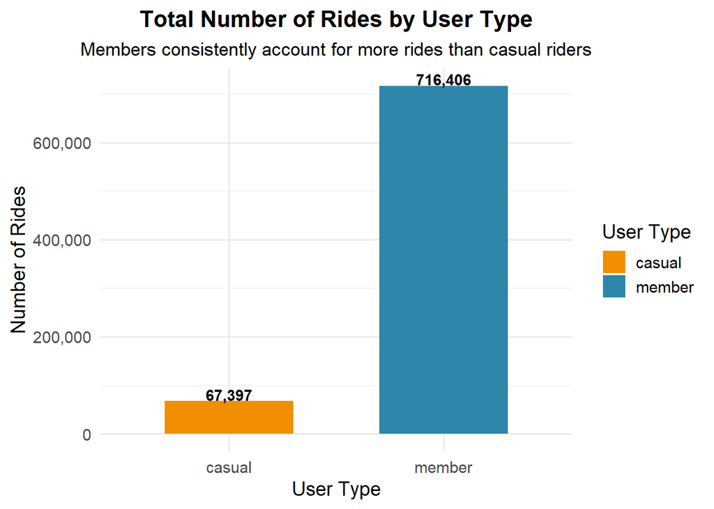

```r
num_of_rides <- all_trips_df %>%
  group_by(member_casual) %>%
  summarise(ride_count = n(), .groups = "drop")

ggplot(num_of_rides, aes(x = member_casual, y = ride_count, fill = member_casual)) +
  geom_col(width = 0.6) +
  labs(
    title = "Total Number of Rides by User Type",
    subtitle = "Members consistently account for more rides than casual riders",
    x = "User Type", y = "Number of Rides", fill = "User Type"
  ) +
  scale_y_continuous(labels = comma) +
  scale_fill_manual(values = c("member" = "#2E86AB", "casual" = "#F18F01")) +
  geom_text(aes(label = comma(ride_count)), vjust = -0.08, fontface = "bold") +
  theme_minimal(base_size = 14) +
  theme(
    plot.title = element_text(hjust = 0.5, size = 16, face = "bold"),
    plot.subtitle = element_text(hjust = 0.5, size = 13)
  )
```

### 6.0.2 Visualization 2: Ride Patterns by Day of Week

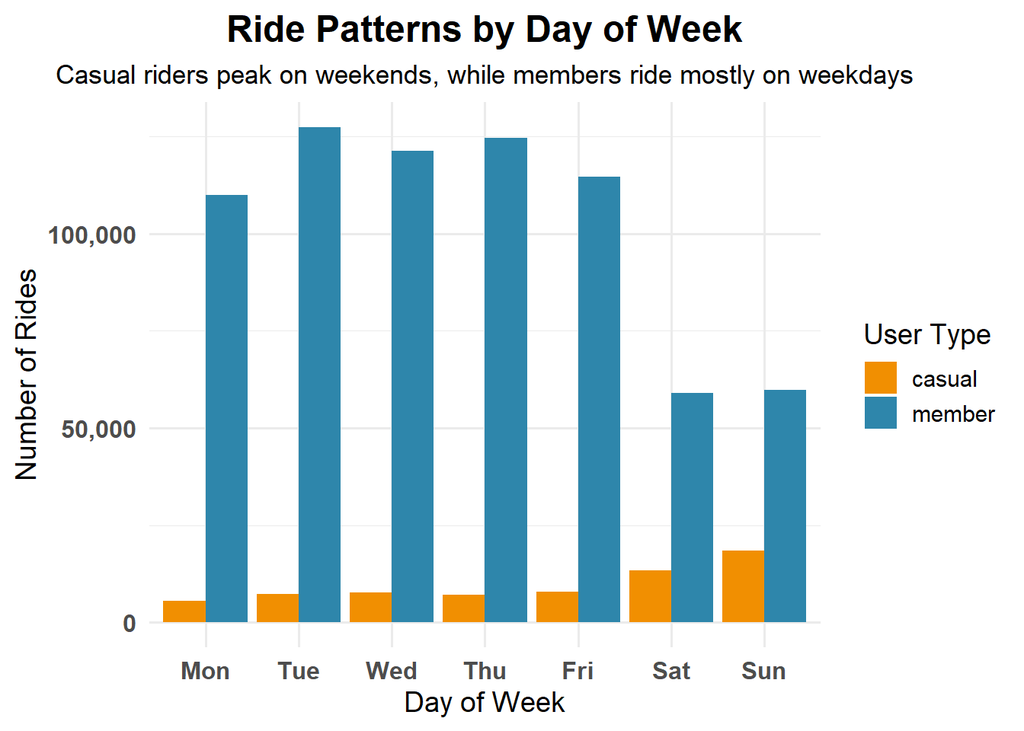

```r
rides_by_day <- all_trips_df %>%
  group_by(member_casual, day_of_week) %>%
  summarise(num_rides = n(), .groups = "drop") %>%
  mutate(day_of_week = factor(day_of_week,
                              levels = c("Mon", "Tue", "Wed", "Thu", "Fri", "Sat", "Sun")))

ggplot(rides_by_day, aes(x = day_of_week, y = num_rides, fill = member_casual)) +
  geom_col(position = "dodge") +
  labs(
    title = "Ride Patterns by Day of Week",
    subtitle = "Casual riders peak on weekends, while members ride mostly on weekdays",
    x = "Day of Week", y = "Number of Rides", fill = "User Type"
  ) +
  scale_y_continuous(labels = comma) +
  scale_fill_manual(values = c("member" = "#2E86AB", "casual" = "#F18F01")) +
  theme_minimal(base_size = 14) +
  theme(
    plot.title = element_text(hjust = 0.5, size = 18, face = "bold"),
    plot.subtitle = element_text(hjust = 0.5, size = 13),
    axis.text.x = element_text(size = 12, face = "bold"),
    axis.text.y = element_text(size = 12, face = "bold")
  )
```

### 6.0.3 Visualization 3: Average Ride Length by User Type

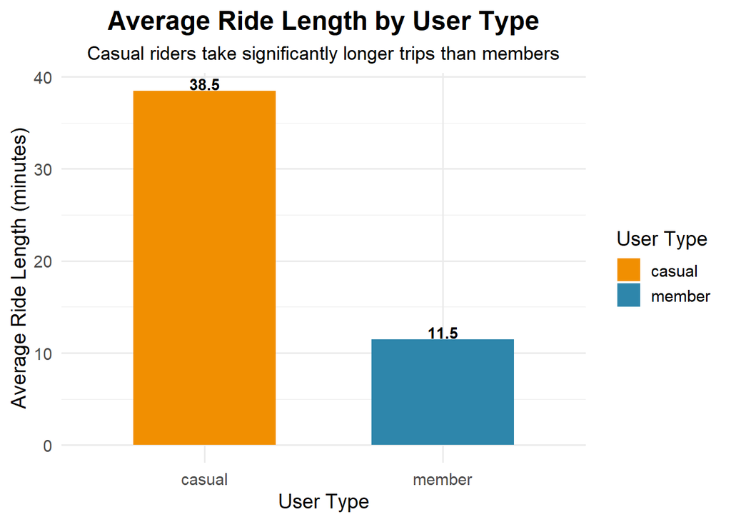

```r
avg_ride_length <- all_trips_df %>%
  group_by(member_casual) %>%
  summarise(avg_length = mean(ride_length_min), .groups = "drop")

ggplot(avg_ride_length, aes(x = member_casual, y = avg_length, fill = member_casual)) +
  geom_col(width = 0.6) +
  labs(
    title = "Average Ride Length by User Type",
    subtitle = "Casual riders take significantly longer trips than members",
    x = "User Type", y = "Average Ride Length (minutes)", fill = "User Type"
  ) +
  scale_y_continuous(labels = comma) +
  scale_fill_manual(values = c("member" = "#2E86AB", "casual" = "#F18F01")) +
  geom_text(aes(label = round(avg_length, 1)), vjust = -0.08, fontface = "bold") +
  theme_minimal(base_size = 14) +
  theme(
    plot.title = element_text(hjust = 0.5, size = 18, face = "bold"),
    plot.subtitle = element_text(hjust = 0.5, size = 13)
  )
```

### 6.0.4 Visualization 4: Monthly Trends by User Type

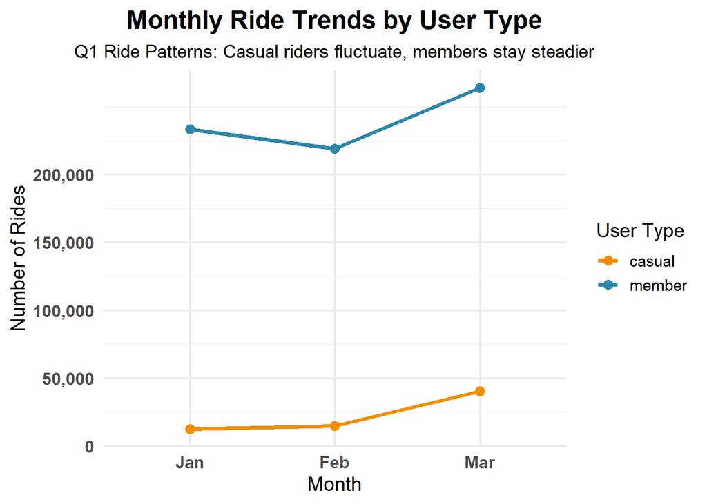

```r
rides_by_month <- all_trips_df %>%
  group_by(member_casual, month) %>%
  summarise(num_rides = n(), .groups = "drop") %>%
  mutate(month = factor(month, levels = c("Jan", "Feb", "Mar")))

ggplot(rides_by_month, aes(x = month, y = num_rides, color = member_casual, group = member_casual)) +
  geom_line(linewidth = 1.3) +
  geom_point(size = 3) +
  labs(
    title = "Monthly Ride Trends by User Type",
    subtitle = "Q1 Ride Patterns: Casual riders fluctuate, members stay steadier",
    x = "Month", y = "Number of Rides", color = "User Type"
  ) +
  scale_y_continuous(
    labels = comma,
    breaks = seq(0, 200000, 50000)   # <<< custom intervals
  ) +
  scale_color_manual(values = c("member" = "#2E86AB", "casual" = "#F18F01")) +
  theme_minimal(base_size = 14) +
  theme(
    plot.title = element_text(hjust = 0.5, size = 18, face = "bold"),
    plot.subtitle = element_text(hjust = 0.5, size = 13),
    axis.text.x = element_text(size = 12, face = "bold"),
    axis.text.y = element_text(size = 12, face = "bold")
  )
```

### 6.0.5 Visualization 5: Top 5 Start Stations by User Type

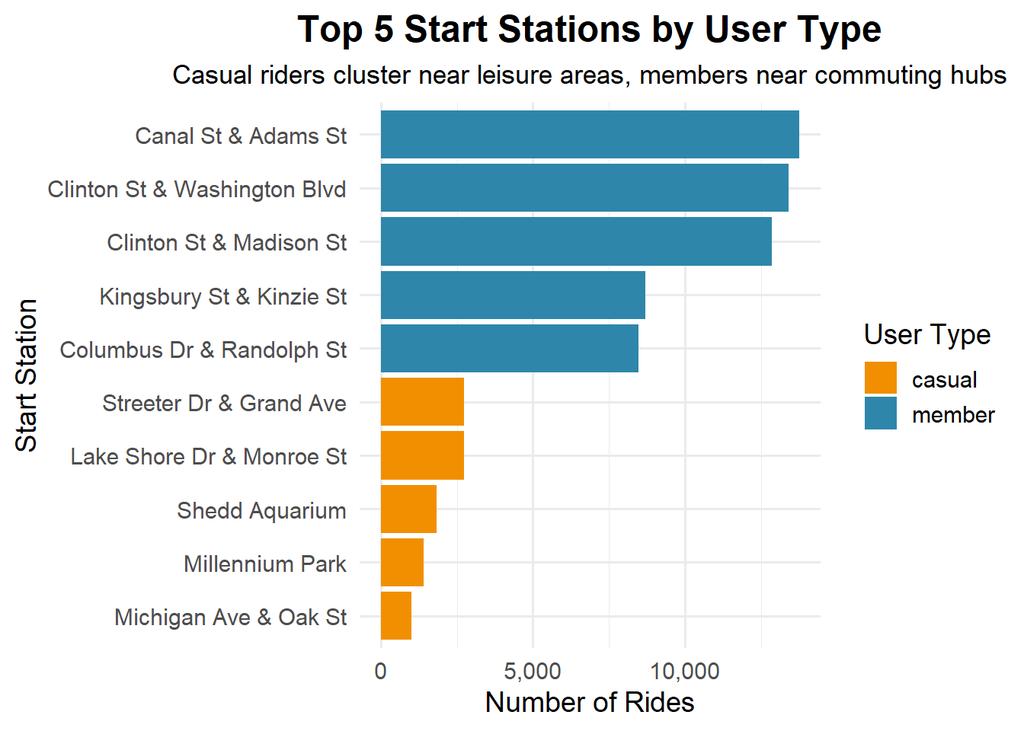

```r
top_stations <- all_trips_df %>%
  group_by(member_casual, start_station_name) %>%
  summarise(num_rides = n(), .groups = "drop") %>%
  group_by(member_casual) %>%
  slice_max(order_by = num_rides, n = 5)

ggplot(top_stations, aes(x = reorder(start_station_name, num_rides), y = num_rides, fill = member_casual)) +
  geom_col(position = "stack") +
  coord_flip() +
  labs(
    title = "Top 5 Start Stations by User Type",
    subtitle = "Casual riders cluster near leisure areas, members near commuting hubs",
    x = "Start Station", y = "Number of Rides", fill = "User Type"
  ) +
  scale_y_continuous(labels = comma) +
  scale_fill_manual(values = c("member" = "#2E86AB", "casual" = "#F18F01")) +
  theme_minimal(base_size = 14) +
  theme(
    plot.title = element_text(hjust = 0.5, size = 18, face = "bold"),
    plot.subtitle = element_text(hjust = 0.5, size = 13)
  )
```

# 7 Conclusion

The analysis showed clear differences between **annual members** and **casual riders**:

- Annual members tend to ride more during weekdays, especially for commuting.
- Casual riders ride more on weekends and for leisure trips.
- Members generally take shorter rides, while casual riders have longer ride durations.

# 8 Recommendations

1. Target casual riders with marketing campaigns that highlight the cost savings and convenience of becoming a member.
2. Offer special promotions during weekends to convert frequent casual riders into members.
3. Improve infrastructure around popular weekend leisure spots to encourage casual riders to join as members.

By implementing these strategies, Cyclistic can increase **member conversions**, leading to **higher long-term revenue**.